# TRY1

2022-12-01

# The Central Limit Theorem

The Central Limit Theorem (CLT) states that the sample mean of identically distributed independent random variables is approximately normally distributed if the sample size is large. This is true for virtually any distribution! We illustrate the Central Limit Theorem using draws from a Poisson distribution.

We begin recalling that if $x \sim Poisson(\lambda)$, then $E[x] = \lambda$ and $Var[x] = \lambda$, where lambda represents the mean number of events. We illustrate the Central Limit Theorem by simulating 4000 times an experiment in which we take random draws from a Poisson distribution with $\lambda = 35$ for three sample sizes: 15, 50, and 800.

Set-up:

- sample size 15,50 and 800
- true $\lambda = 35$
- so that expected value and variance are both equal to 35

```
##        V1                  V2                 V3
##  Min.   :-3.884278   Min.   :-3.80083   Min.   :-3.334688
##  1st Qu.:-0.654654   1st Qu.:-0.64542   1st Qu.:-0.645423
##  Median : 0.000000   Median : 0.02390   Median : 0.000000
##  Mean   :-0.004059   Mean   : 0.03623   Mean   : 0.009353
##  3rd Qu.: 0.654654   3rd Qu.: 0.69323   3rd Qu.: 0.693233
##  Max.   : 3.622417   Max.   : 3.94425   Max.   : 3.400425
```

We then provide some graphical representations

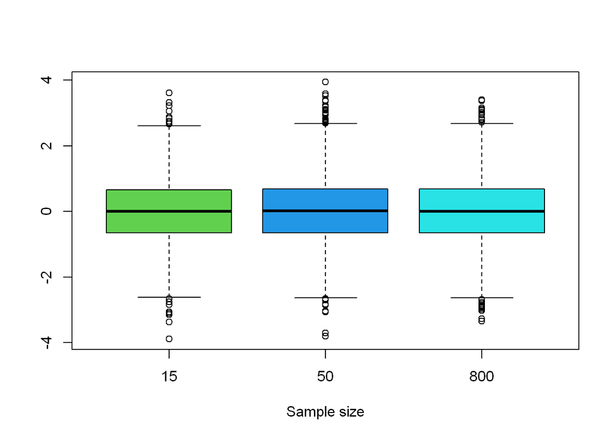

```r
#### Hystograms and boxplot with ggplot

z.data <- data.frame(
  val = as.vector(z),
  sample.size = as.factor(rep(m, each = sims))
)

require(ggplot2); require(ggpubr)
# the default boxplot function

boxplot(z,
        xlab = "Sample size",
        col = 3:5,
        names = m,
        horisontal = F)
```

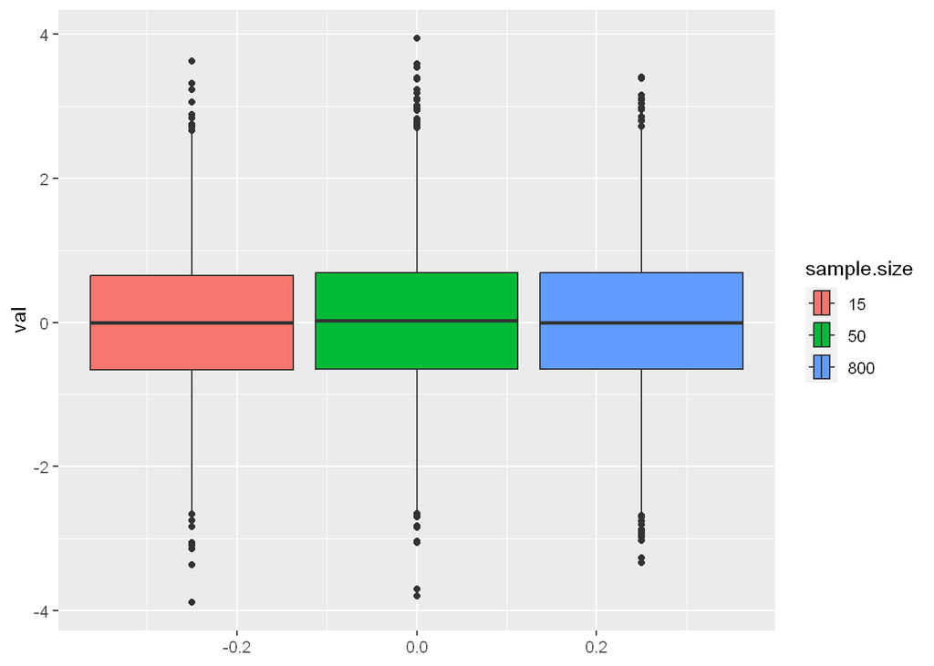

```r
ggplot(data = z.data,
       aes(x = val, fill = sample.size))+
  geom_boxplot()+
  coord_flip()
```

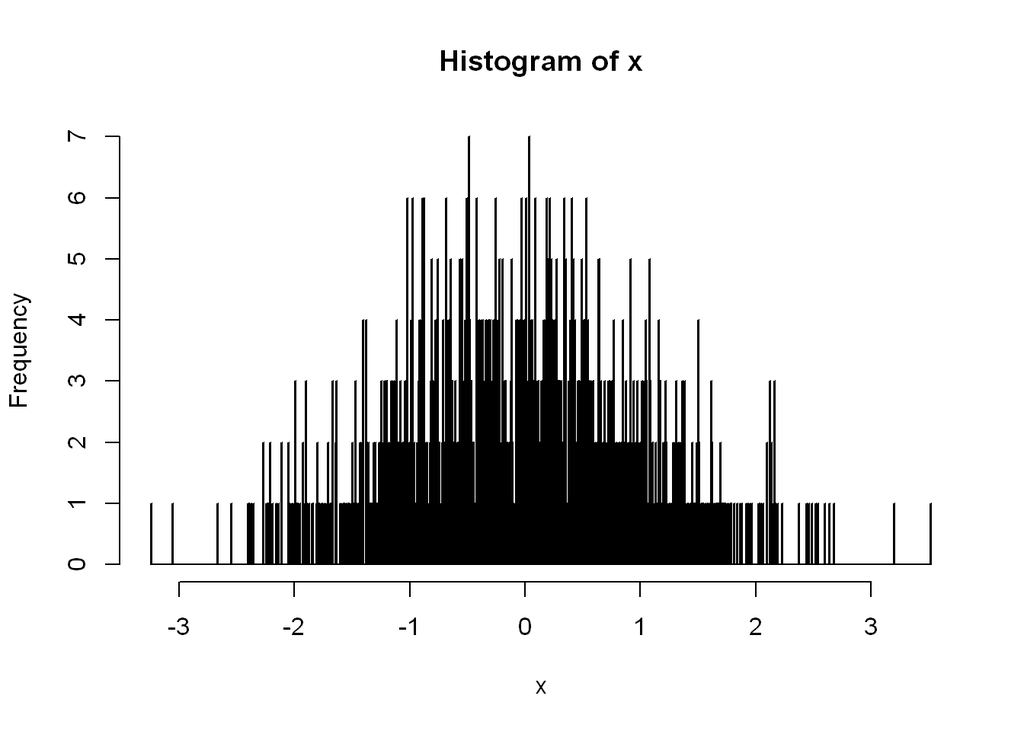

```r
#### histogram

graph1 <- ggplot(z.data, aes(x = val,
                   y = stat(density),
                   fill = sample.size))+
  labs(x = 'z', y = 'f(z)')+
  geom_histogram(bins = 80)

graph11 <- graph1 + facet_grid(sample.size ~ .)


##### density estimation

set.seed(3)
x<- rnorm(1300)
hist(x, breaks = 1000)
```

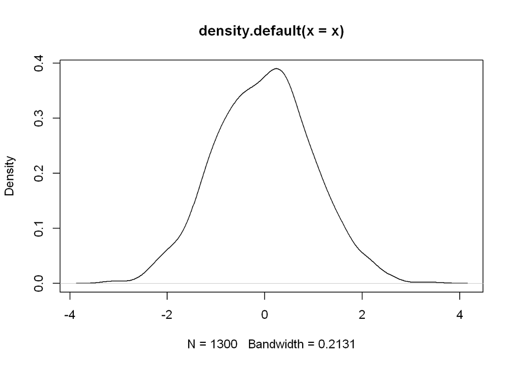

```r
plot(density(x))
```

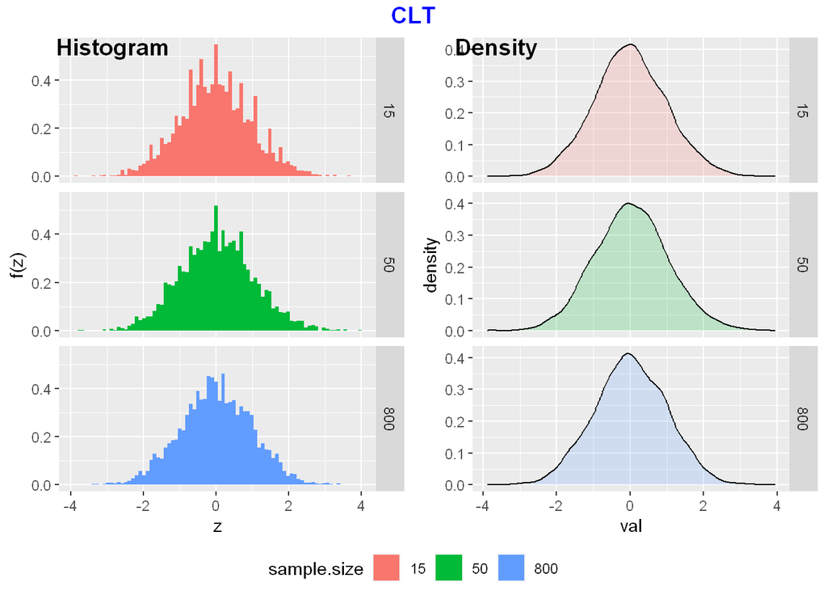

```r
graph2 <- ggplot(z.data, aes(x = val, fill =  sample.size))+
  geom_density(alpha = .2)

graph22 <- graph2 + facet_grid(sample.size ~ .)


combined.plot <- ggarrange(graph11,
          graph22,
          ncol = 2,
          common.legend = T,
          legend = "bottom",
          labels = c("Histogram", "Density"))
annotate_figure(
  combined.plot,
  top = text_grob(
    'CLT', color = 'blue', face = 'bold', size = 14
  )
)
```

We calculate and store the Z-score for the mean of each sample size. Note: Recall the command matrix(data,nrow=X, ncol=Y) will create a matrix with X rows and Y columns, and fill those spaces with a vector of data.

[figure not shown]

```r
summary(rgeom(100, 0.7))
```

```
   Min. 1st Qu.  Median    Mean 3rd Qu.    Max.
   0.00    0.00    0.00    0.39    1.00    3.00
```